# R Notebook: Market Test - Fruitazia

## Packages

Make sure the following packages are installed before proceeding:

1. ggpubr
2. knitr

```r
library("ggpubr") # anova visualization
library("knitr") # used for report compilation and table display
```

## Market test

In this notebook we will explore how statistical analysis can help us determine advertising effectiveness using market test data.

## Data

We will work with *fruitazia.csv* file. The data presents results of a market test for fruit juice with 2 advertising levels $\times$ 3 price levels, which gives us 6 experimental conditions, with 5 supermarkets per condition.

```r
# loading data
data <- read.csv(file = "fruitazia.csv")
data$AdSpend <- as.factor(data$AdSpend)
data$Price <- as.factor(data$Price)
data
```

```
##    Sales Price AdSpend AdSpend2 Price4.9 Price5.9
## 1    499   3.9       1        0        0        0
## 2    595   3.9       1        0        0        0
## 3    496   3.9       1        0        0        0
## 4    607   3.9       1        0        0        0
## 5    550   3.9       1        0        0        0
## 6    989   3.9       2        1        0        0
## 7    721   3.9       2        1        0        0
## 8    823   3.9       2        1        0        0
## 9   1001   3.9       2        1        0        0
## 10   881   3.9       2        1        0        0
## 11   382   4.9       1        0        1        0
## 12   429   4.9       1        0        1        0
## 13   410   4.9       1        0        1        0
## 14   500   4.9       1        0        1        0
```

[output cut: 16 more lines]

## Data summary

Let us see sales averages by price and ad spend levels.

```r
kable(aggregate(Sales ~ Price + AdSpend, data=data, FUN=mean))
```

| Price | AdSpend | Sales |
| --- | --- | --- |
| 3.9 | 1 | 549.4 |
| 4.9 | 1 | 430.2 |
| 5.9 | 1 | 377.4 |
| 3.9 | 2 | 883.0 |
| 4.9 | 2 | 642.6 |
| 5.9 | 2 | 436.8 |

Here is how we can plot the means and other supporting information.

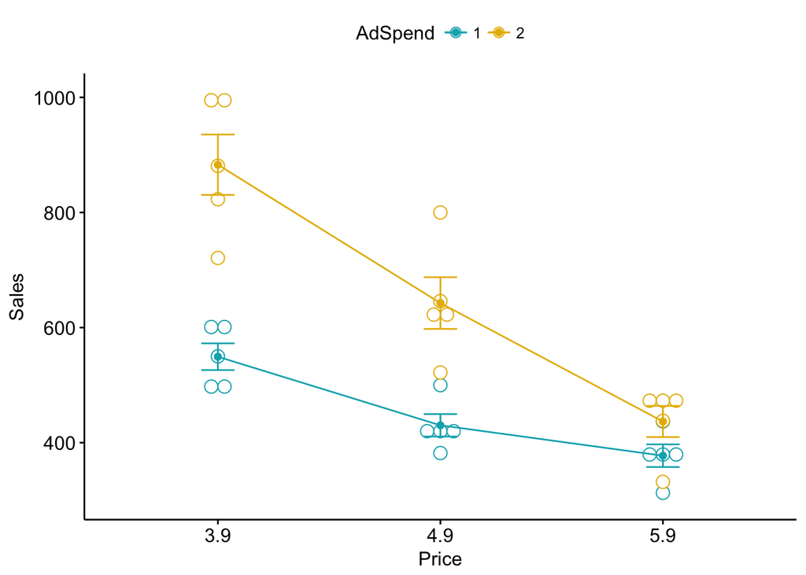

```r
ggline(data, x = "Price", y = "Sales", color = "AdSpend",
       add = c("mean_se", "dotplot"), palette = c("#00AFBB", "#E7B800"))
```

## ANOVA - no interaction terms

Here is how we perform basic analysis of variance using *lm()* function. All effects are highly statistically significant at $0.05$ level. When we use *anova()* command on the *lm()* output, we obtain information about the overall significance of each factor, rather than of a specific level of a factor.

```r
model <- lm(Sales ~ Price + AdSpend, data=data)
summary(model)
```

```
##
## Call:
## lm(formula = Sales ~ Price + AdSpend, data = data)
##
## Residuals:
##     Min      1Q  Median      3Q     Max
## -176.00  -50.38   -7.40   64.35  183.90
##
## Coefficients:
##             Estimate Std. Error t value Pr(>|t|)
## (Intercept)   615.30      34.39  17.893 3.89e-16 ***
## Price4.9     -179.80      42.12  -4.269 0.000231 ***
## Price5.9     -309.10      42.12  -7.339 8.56e-08 ***
## AdSpend2      201.80      34.39   5.868 3.46e-06 ***
## ---
## Signif. codes:  0 '***' 0.001 '**' 0.01 '*' 0.05 '.' 0.1 ' ' 1
##
## Residual standard error: 94.17 on 26 degrees of freedom
## Multiple R-squared:  0.7735, Adjusted R-squared:  0.7474
## F-statistic: 29.59 on 3 and 26 DF,  p-value: 1.537e-08
```

```r
anova(model)
```

```
## Analysis of Variance Table
##
## Response: Sales
##           Df Sum Sq Mean Sq F value    Pr(>F)
## Price      2 481964  240982  27.172 4.268e-07 ***
## AdSpend    1 305424  305424  34.439 3.459e-06 ***
## Residuals 26 230585    8869
## ---
## Signif. codes:  0 '***' 0.001 '**' 0.01 '*' 0.05 '.' 0.1 ' ' 1
```

## ANOVA - with interactions

Here is how we perform the same analysis with interaction terms between ad spend and price levels added in. We see that advertising is less effective at higher price levels. This interaction effect is statistically significant at $0.05$ level only for $\$5.9$ price.

```r
model1 <- lm(Sales ~ Price * AdSpend, data=data)
summary(model1)
```

```
##
## Call:
## lm(formula = Sales ~ Price * AdSpend, data = data)
##
## Residuals:
##     Min      1Q  Median      3Q     Max
## -162.00  -43.80    0.20   39.45  157.40
##
## Coefficients:
##                   Estimate Std. Error t value Pr(>|t|)
## (Intercept)         549.40      33.69  16.309 1.73e-14 ***
## Price4.9           -119.20      47.64  -2.502 0.019565 *
## Price5.9           -172.00      47.64  -3.610 0.001401 **
## AdSpend2            333.60      47.64   7.002 3.06e-07 ***
## Price4.9:AdSpend2  -121.20      67.37  -1.799 0.084625 .
## Price5.9:AdSpend2  -274.20      67.37  -4.070 0.000442 ***
## ---
## Signif. codes:  0 '***' 0.001 '**' 0.01 '*' 0.05 '.' 0.1 ' ' 1
##
## Residual standard error: 75.33 on 24 degrees of freedom
## Multiple R-squared:  0.8662, Adjusted R-squared:  0.8384
## F-statistic: 31.08 on 5 and 24 DF,  p-value: 9.777e-10
```

```r
anova(model1)
```

```
## Analysis of Variance Table
##
## Response: Sales
##               Df Sum Sq Mean Sq F value    Pr(>F)
## Price          2 481964  240982 42.4697 1.307e-08 ***
## AdSpend        1 305424  305424 53.8267 1.410e-07 ***
## Price:AdSpend  2  94403   47202  8.3186  0.001801 **
## Residuals     24 136181    5674
## ---
## Signif. codes:  0 '***' 0.001 '**' 0.01 '*' 0.05 '.' 0.1 ' ' 1
```